# 第10回 出だしの不運を直す

## 在庫だけで書く帳簿の読み違い

状態の書き方

(残りの人数, 在庫)

これまでは値段ごとに平均を書いた  
同じ値段でも、状態が違うと、その先に残るものが違う

✕ 帳簿に在庫だけ書く

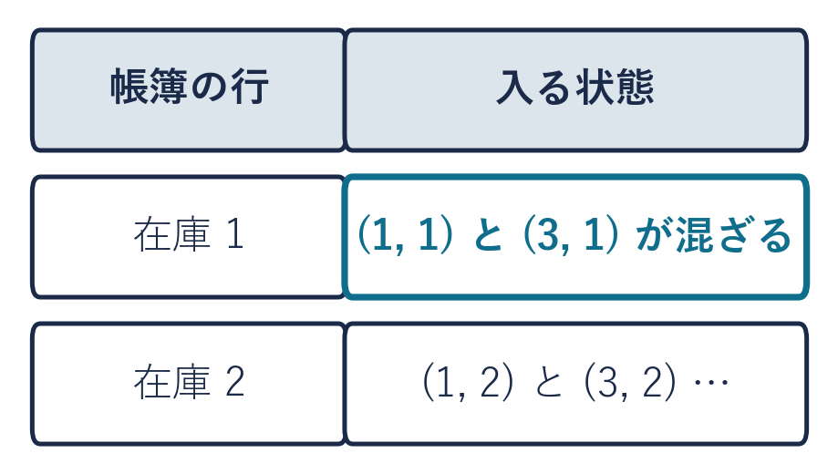

○ 状態の組で書く

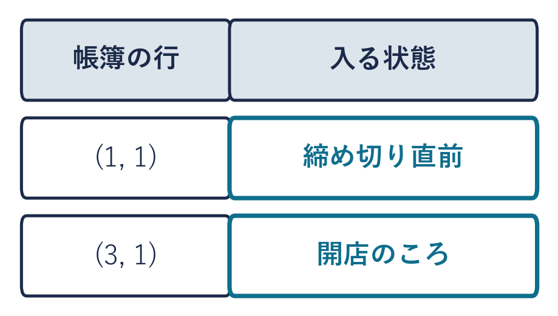

残りの人数を落とすと、締め切り直前と開店のころが混ざる

## 状態が変わらない店と状態が動く店

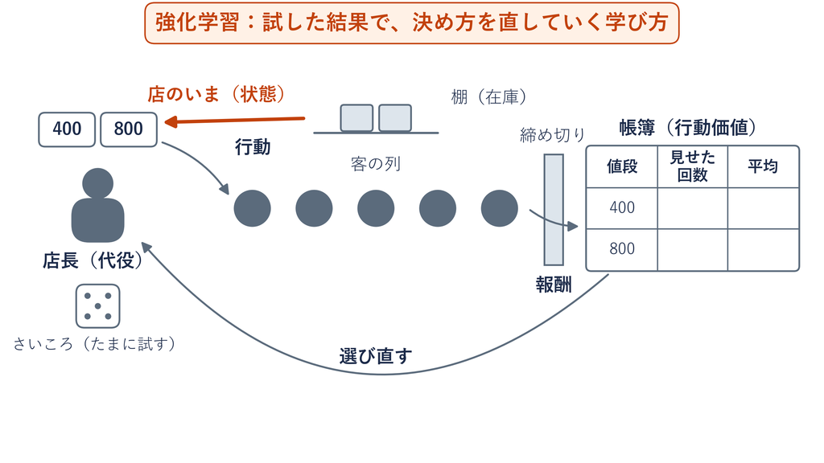

ここまでの店：状態が変わらない店（前に見たバンディット）  
1 点ものの店：選んだ値段で店のいま（状態）が変わる

## 12 の状態を書き出す写経

状態の書き方

(残りの人数, 在庫)

残り 6 人・在庫 2 個までだと、状態は 12 個。手で書くと書き漏らすので、コードで出す

```python
for rest in range(1, 7):        # 残りの人数：1〜6 人
    for stock in [1, 2]:        # 在庫：1 個か 2 個
        print((rest, stock))    # 状態（残りの人数, 在庫）
```

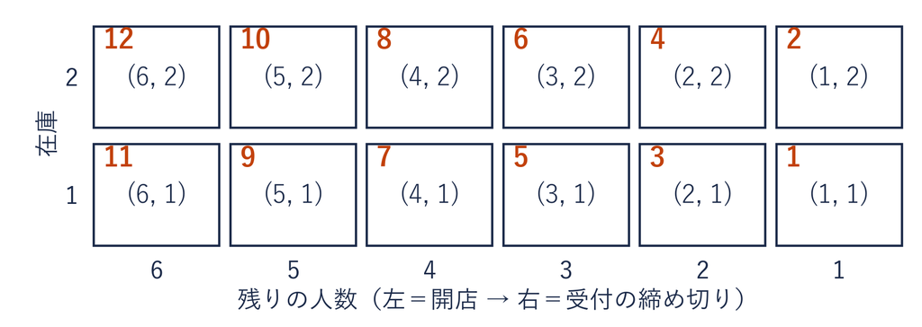

図は時間の進む左 → 右、出力は残り 1 人から（マスの左上の数が表示の順・右から左へ）  
3 行目の括弧は 2 重：外が print の括弧、内側が (残りの人数, 在庫) の組の括弧

**STEP 1** **＋ コード**でセルを足し、3 行を写して実行 **STEP 2** (1, 1) から (6, 2) まで 12 行出たか数える

⏸ PAUSE 止めて Colab で写して実行（目安 5 分）。12 行が出たら再生に戻る

## 演習4 在庫 3 個までの状態

状態の書き方

(残りの人数, 在庫)

演習 4

在庫を 3 個までにすると、状態はいくつになるか

```python
for rest in range(1, 7):        # 残りの人数：1〜6 人
    for stock in [1, 2]:        # ← ここを [1, 2, 3] に
        print((rest, stock))    # 状態（残りの人数, 在庫）
```

1. **書き換える**：写経のセルをコピーして **＋ コード**で足したセルに貼り  
   2 行目の [1, 2] を [1, 2, 3] に
2. **予想する**：状態は 12 個より何個増えるか
3. **終わり**：実行して、出た行を数えたら

⏸ PAUSE 動画を止めて $3$ 分。行を数えたら再生に戻る

## 演習4の答え

状態の書き方

(残りの人数, 在庫)

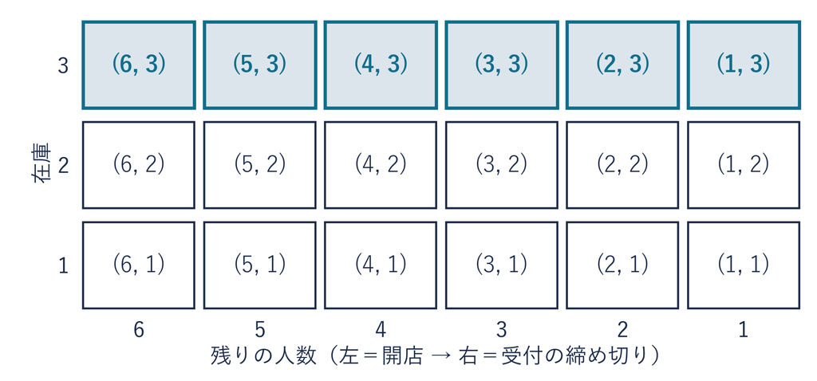

- **答え**：18 個。在庫 3 の行に (1, 3) から (6, 3) の 6 マスが増える
- **数え方**：残りの人数 6 通り × 在庫 3 通り ＝ 18

組にする数の種類が増えると、状態の数は掛け算で増える

## 予想の封印

いまの状態（残りの人数, 在庫）

(2, 1)

品が 1 点しかなく、残りの人数は 2 人（状態は (2, 1)）  
1 人目に見せる値段は？

- **①** 400 円
- **②** 800 円
- **③** どちらでも同じ

動画を止めて 1 分。1 つ選び、理由を 1 行  
小課題ノートの段 4 の最後、封印のテキストセルに書く  
答えは、次の回で、計算して開ける

## まとめ

疑問 在庫 1 個で、残り 1 人と残り 30 人では、  
値段の選び方は同じか

回答 同じとは限らない  
残りの人数が違えば、別の状態として考える

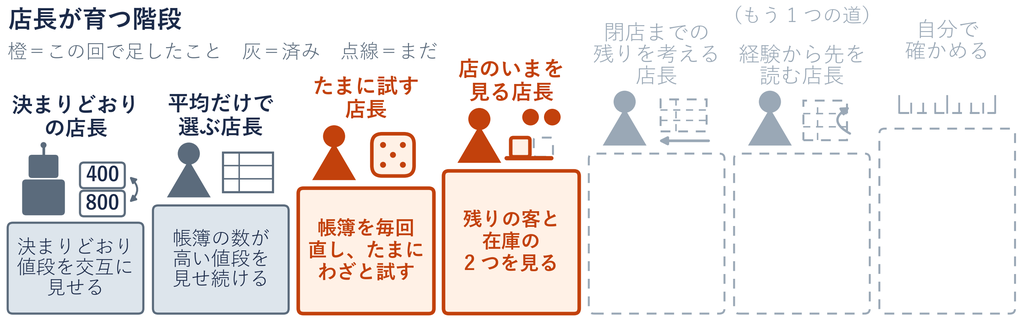

## 今日の 4 つの疑問と回答

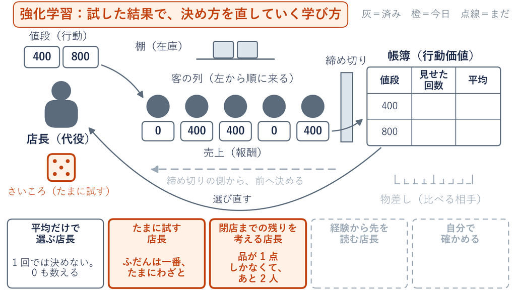

|  | 疑問 | 回答 |
| --- | --- | --- |
| T1 | 1 回売れなかった 400 円が 2 回目に売れ たら、平均はどう直すか | ずれの n 分の 1 だけ直す |
| T2 | たまにわざと試す店長なら、 400 円をもう一度客に見せるか | 見せる。試す客には、平均を見ずに値段を選ぶ |
| T3 | いつも試したほうが得か | いつもではない。誤解を直す機会と、 試しの費用の両方がある |
| T4 | 在庫 1 個で、残り 1 人と残り 30 人では 選び方は同じか | 同じとは限らない。 残りの人数と在庫の組で、店のいまを書く |

やること：小課題ノートを上から実行して、manaba へ